# GroDataDmorv — Analyse de l’équilibrage de Pokémon

## 20. Comment ont évolué les caractéristiques biologiques telles que la taille, le poids ou le dimorphisme sexuel au fil des générations ? (`pokemon.csv`, `pokemon_species.csv`)

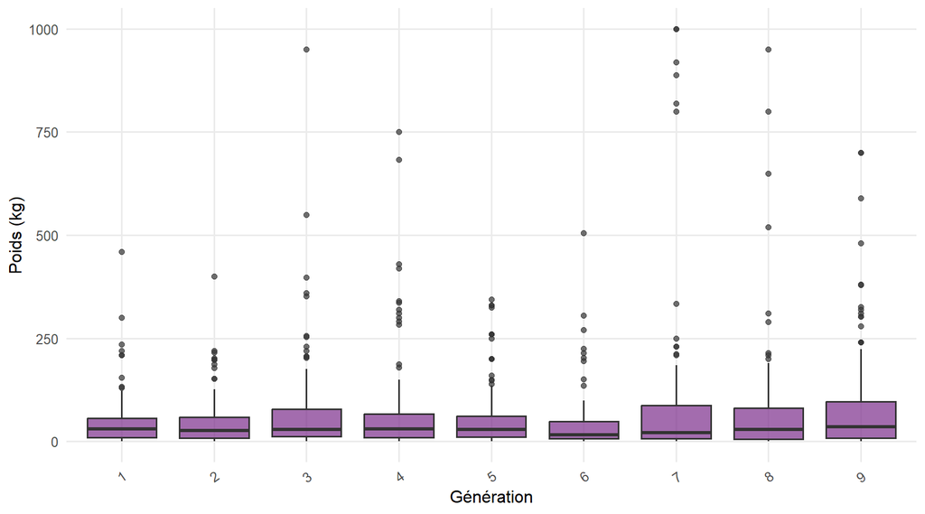

La moyenne a augmenté, passant de 46 kg (gén. 1) à 87.3 kg (gén. 9). La médiane (35 kg en dernière génération) reste bien inférieure à la moyenne, signe que quelques espèces très lourdes (légendaires notamment) tirent les valeurs vers le haut.

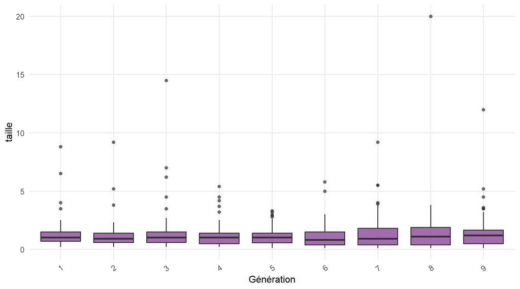

La moyenne a augmenté, passant de 1.2 m (gén. 1) à 1.4 m (gén. 9). La médiane (1.2 m en dernière génération) reste bien inférieure à la moyenne, signe que quelques espèces très grandes (légendaires notamment) tirent les valeurs vers le haut.

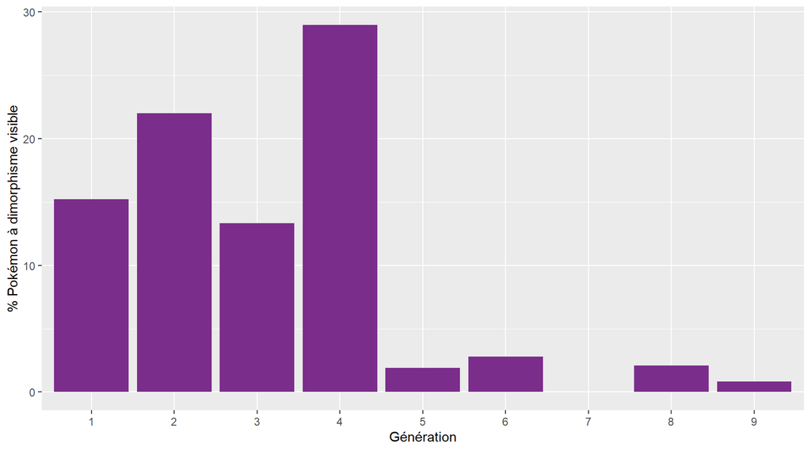

Le dimorphisme sexuel visible (apparence différente entre mâle et femelle) concerne en moyenne 10% des espèces. Il culmine en génération 4 (29%), qui correspond aux jeux Diamant/Perle où cette mécanique a été fortement développée. Ce critère ne capture que les différences d’apparence, pas les différences de répartition mâle/femelle au sein des espèces.

# Shiny App

[figure not shown]

A gauche, une barre de navigation propose les sections Stats, Rencontres et Bestiaires, ainsi qu’un sélecteur de région (ici réglé sur Unova). La zone principale présente le nombre total d’espèces (1025) et celles présentes dans la région (156), suivi de quatre cartes mettant en avant le Pokémon le plus lourd, le plus léger, le plus grand et le plus petit, chacun avec son image et sa mesure. Une dernière carte affiche la carte de la région.

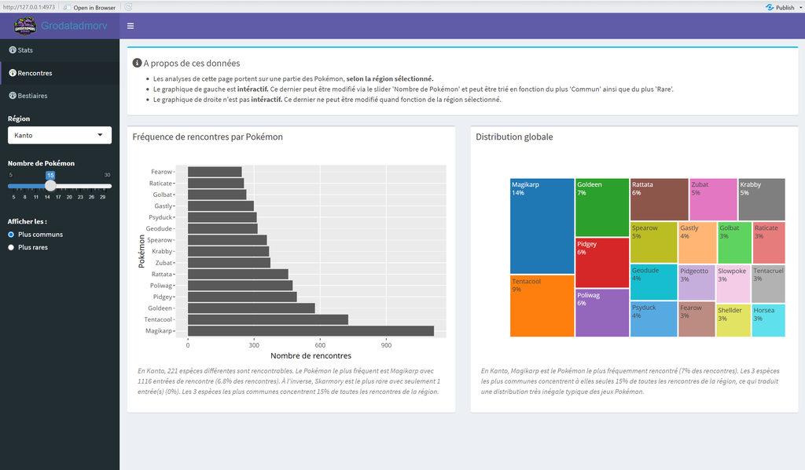

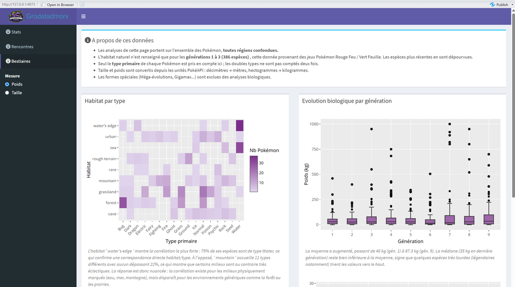

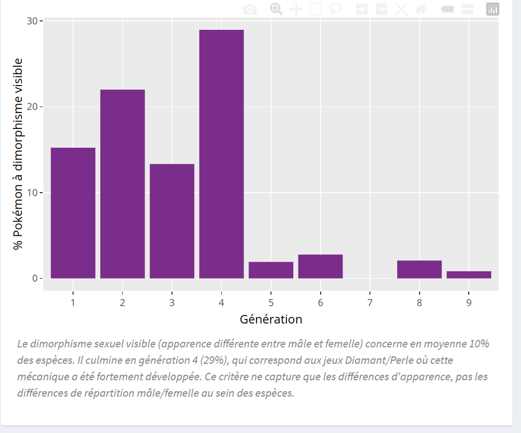

On retrouve aussi un troisième graphique en barre représentant le pourcentage de pokémon présentant un dimorphisme par génération.

# Limites

- **Hétérogénéité entre générations :** les statistiques, les attaques, les mécaniques et parfois même le type des Pokémon évoluant d’une génération à l’autre, croiser plusieurs générations sans les filtrer strictement peut engendrer des incohérences.
- **Biais de popularité :** l’usage joueur ne mesure pas toujours la puissance intrinsèque d’un Pokémon.
- **Complexité d’agrégation :** évaluer mathématiquement un Pokémon pour la visualisation implique de faire l’impasse sur des détails contextuels ; la viabilité se base fortement sur les spécificités uniques des attaques et des talents (Ability), ce qui est difficilement réductible à des statistiques globales sans perte sémantique.
- **Nature complexe de l’angle RPG :** des paramètres majeurs de la difficulté (“IA” de jeu, utilisation d’objets curatifs par les PNJ, composition des arènes) ne sont pas quantifiables via nos données actuelles.